# Cities prelim analysis

Jeff Witmer

11/1/2020

We now have data entered for 32 cities on each of several variables. This now includes police demographics.

```r
## Libraries to include
library(tidyverse)
library(mosaic)
## Load the data
library(readxl)
#NewCities <- read_excel("New Cities Database copy late reduced 10-27-20.xlsx")
#NewCities <- read_excel("New Cities Database copy 10-28-20.xlsx")
NewCities <- read_excel("New Cities Database copy noNAs 11-1-20.xlsx")
```

Look at the structure of the datafile.

```r
str(NewCities)
```

```
tibble [279 × 18] (S3: tbl_df/tbl/data.frame)
 $ City               : chr [1:279] "Austin" "Bakersfield" "Burlington" "Charlotte" ...
 $ year               : num [1:279] 2018 2018 2018 2018 2018 ...
 $ partialYearMonths  : num [1:279] NA 3 NA NA 5 NA NA NA NA NA ...
 $ BlackPop           : num [1:279] 92981 38340 2341 368522 139765 ...
 $ WhitePop           : num [1:279] 864981 341732 40343 500043 163398 ...
 $ StanfordStopsBl    : num [1:279] NA 489 NA NA 4986 ...
 $ StanfordStopsWh    : num [1:279] NA 1171 NA NA 2778 ...
 $ BlackProp          : num [1:279] NA 0.051 NA NA 0.0856 ...
 $ WhiteProp          : num [1:279] NA 0.0137 NA NA 0.0408 ...
 $ DiffBlackMinusWhite: num [1:279] NA 0.0373 NA NA 0.0448 ...
 $ RatioBlackWhite    : num [1:279] NA 3.72 NA NA 2.1 ...
 $ animus_score       : num [1:279] 52.5 57.5 51.1 73 71.8 ...
 $ implicit_score_mean: num [1:279] 0.254 0.21 0.307 0.276 0.297 ...
 $ implicit_nobs      : num [1:279] 3202 459 1072 3654 4640 ...
 $ Region             : chr [1:279] "South" "West" "Northeast" "South" ...
 $ WhitePoliceShare   : num [1:279] 69.2 75 92 77.2 66.1 86.4 64.4 71.9 75.8 64.7 ...
 $ BlackPolShare      : num [1:279] 8.7 3.4 2 16.5 30.6 11.3 29.6 18.6 19.6 12.4 ...
 $ PoliceRatioWhBl    : num [1:279] 7.95 22.06 46 4.68 2.16 ...
```

The primary variables are DiffBlackMinusWhite, RatioBlackWhite, animus_score, and implicit_score_mean.

```r
Cities <- NewCities %>% select(c(City, year, DiffBlackMinusWhite, RatioBlackWhite, animus_score, implicit_score_mean, Region))
dim(Cities)
```

```
[1] 279   7
```

```r
head(Cities)
```

| City | year | DiffBlackMinusWhite | RatioBlackWhite | animus_score | implicit_score_mean | Region |
| --- | --- | --- | --- | --- | --- | --- |
| Austin | 2018 | NA | NA | 52.54 | 0.2540746 | South |
| Bakersfield | 2018 | 0.03731057 | 3.722078 | 57.52 | 0.2095039 | West |
| Burlington | 2018 | NA | NA | 51.07 | 0.3069520 | Northeast |
| Charlotte | 2018 | NA | NA | 73.00 | 0.2759605 | South |
| Cincinti | 2018 | 0.04481456 | 2.098304 | 71.84 | 0.2968426 | Midwest |
| Columbus | 2018 | NA | NA | 75.69 | 0.2378166 | Midwest |

A scatterplot matrix.

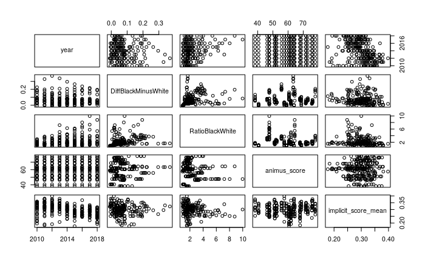

```r
plot(Cities[2:6])
```

There are a few high points for RatioBlackWhite. They are for California:

```r
Cities[order(Cities$RatioBlackWhite, decreasing = TRUE),]
```

| City | year | DiffBlackMinusWhite | RatioBlackWhite | animus_score | implicit_score_mean | Region |
| --- | --- | --- | --- | --- | --- | --- |
| Oakland | 2017 | 0.083856446 | 9.9785590 | 47.64 | 0.3000461 | West |
| Los Angeles | 2018 | 0.195126024 | 8.7796250 | 64.39 | 0.2480288 | West |
| Oakland | 2016 | 0.079020122 | 8.0256815 | 47.64 | 0.2523143 | West |
| Los Angeles | 2017 | 0.169219175 | 7.3491997 | 64.39 | 0.2655387 | West |
| San Jose | 2013 | 0.022095867 | 7.2036289 | 47.64 | 0.3389044 | West |
| Los Angeles | 2016 | 0.140735230 | 6.9098299 | 64.39 | 0.2525580 | West |
| San Jose | 2016 | 0.017186209 | 6.4433014 | 47.64 | 0.2797560 | West |
| San Jose | 2014 | 0.020664258 | 6.2829610 | 47.64 | 0.2957550 | West |
| San Jose | 2015 | 0.017912964 | 6.2091817 | 47.64 | 0.2930086 | West |
| Oakland | 2015 | 0.052587314 | 6.0000486 | 47.64 | 0.2567872 | West |

[output cut: 269 more lines]

It will be helpful to have R know that Region is a factor.

```r
NewCities$Region <- as.factor(NewCities$Region)
str(NewCities)
```

```
tibble [279 × 18] (S3: tbl_df/tbl/data.frame)
 $ City               : chr [1:279] "Austin" "Bakersfield" "Burlington" "Charlotte" ...
 $ year               : num [1:279] 2018 2018 2018 2018 2018 ...
 $ partialYearMonths  : num [1:279] NA 3 NA NA 5 NA NA NA NA NA ...
 $ BlackPop           : num [1:279] 92981 38340 2341 368522 139765 ...
 $ WhitePop           : num [1:279] 864981 341732 40343 500043 163398 ...
 $ StanfordStopsBl    : num [1:279] NA 489 NA NA 4986 ...
 $ StanfordStopsWh    : num [1:279] NA 1171 NA NA 2778 ...
 $ BlackProp          : num [1:279] NA 0.051 NA NA 0.0856 ...
 $ WhiteProp          : num [1:279] NA 0.0137 NA NA 0.0408 ...
 $ DiffBlackMinusWhite: num [1:279] NA 0.0373 NA NA 0.0448 ...
 $ RatioBlackWhite    : num [1:279] NA 3.72 NA NA 2.1 ...
 $ animus_score       : num [1:279] 52.5 57.5 51.1 73 71.8 ...
 $ implicit_score_mean: num [1:279] 0.254 0.21 0.307 0.276 0.297 ...
 $ implicit_nobs      : num [1:279] 3202 459 1072 3654 4640 ...
 $ Region             : Factor w/ 4 levels "Midwest","Northeast",..: 3 4 2 3 1 1 3 3 3 2 ...
 $ WhitePoliceShare   : num [1:279] 69.2 75 92 77.2 66.1 86.4 64.4 71.9 75.8 64.7 ...
 $ BlackPolShare      : num [1:279] 8.7 3.4 2 16.5 30.6 11.3 29.6 18.6 19.6 12.4 ...
 $ PoliceRatioWhBl    : num [1:279] 7.95 22.06 46 4.68 2.16 ...
```

Let’s look at RatioBlackWhite as a response to a couple of predictors. It seems that I need to use as.factor() despite resetting Region as a factor above.

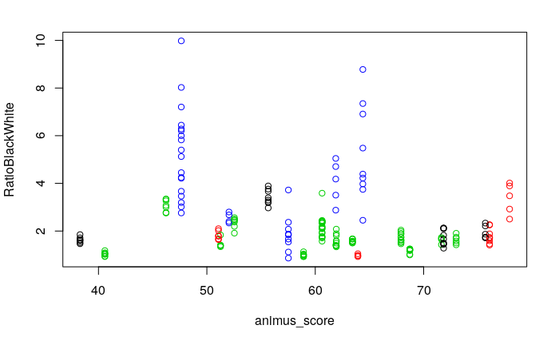

```r
plot(RatioBlackWhite ~ animus_score, col = as.factor(Region), data = Cities)
```

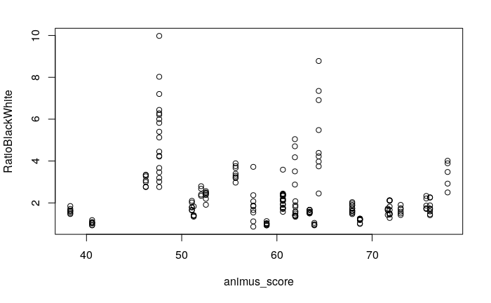

```r
plot(RatioBlackWhite ~ animus_score, data = Cities)
```

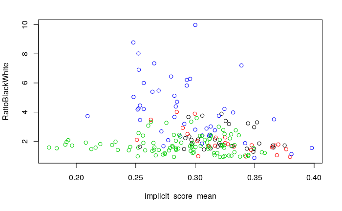

```r
plot(RatioBlackWhite ~ implicit_score_mean, col = as.factor(Region), data = Cities)
```

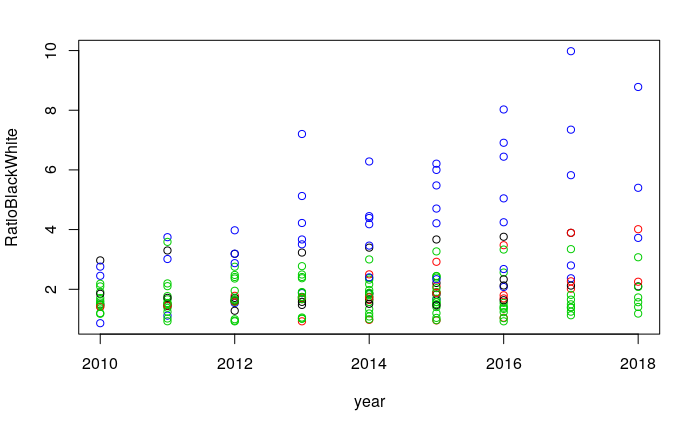

```r
plot(RatioBlackWhite ~ year, col = as.factor(Region), data = Cities)
```

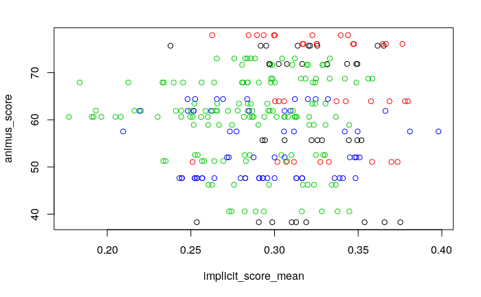

```r
plot(animus_score ~ implicit_score_mean, col = as.factor(Region), data = Cities)
```

The mPlot() command is useful for exploring the data. After using it, I came up with this plot, for example:

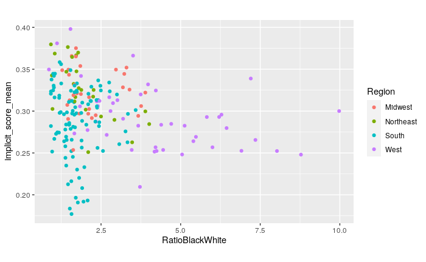

Here is a plot that shows (in log scale) that when WhitePoliceShare is below 60% RatioBlackWhite is high. (Recall that RatioBlackWhite is the relative probability of a Black driver being stopped to that of a White driver being stopped, and is our main response variable of interest.)

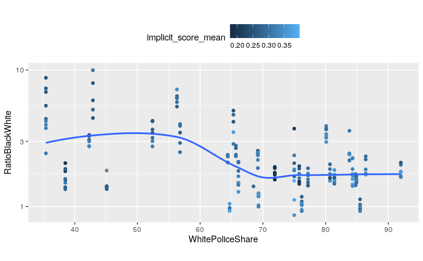

Another graph, not about stops but about implicit mean score and police force demographics.

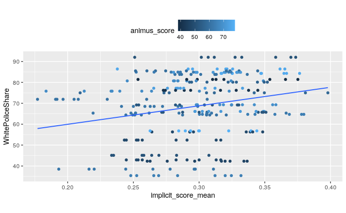

```r
gf_point(WhitePoliceShare ~ implicit_score_mean, data = NewCities, color = ~ animus_score) %>%
gf_lm() %>%
gf_theme(legend.position = "top") %>%
gf_labs(title = "", caption = "")
```

```r
gf_point(WhitePoliceShare ~ animus_score, data = NewCities, color = ~ implicit_score_mean) %>%
gf_lm() %>%
gf_theme(legend.position = "top") %>%
gf_labs(title = "", caption = "")
```

[output not shown]

```
Call:
lm(formula = RatioBlackWhite ~ animus_score + implicit_score_mean,
    data = Cities)

Residuals:
    Min      1Q  Median      3Q     Max
-2.1557 -0.9079 -0.2854  0.3246  7.2190

Coefficients:
                    Estimate Std. Error t value Pr(>|t|)
(Intercept)          6.11596    0.95050   6.434 9.38e-10 ***
animus_score        -0.02899    0.01015  -2.857  0.00474 **
implicit_score_mean -6.58380    2.56669  -2.565  0.01107 *
---
Signif. codes:  0 ‘***’ 0.001 ‘**’ 0.01 ‘*’ 0.05 ‘.’ 0.1 ‘ ’ 1

Residual standard error: 1.483 on 195 degrees of freedom
  (81 observations deleted due to missingness)
Multiple R-squared:  0.07521,   Adjusted R-squared:  0.06573
F-statistic: 7.929 on 2 and 195 DF,  p-value: 0.0004888
```

```
Call:
lm(formula = RatioBlackWhite ~ implicit_score_mean, data = Cities)

Residuals:
    Min      1Q  Median      3Q     Max
-1.7797 -1.0058 -0.4207  0.4676  7.5779

Coefficients:
                    Estimate Std. Error t value Pr(>|t|)
(Intercept)            4.532      0.786   5.766 3.12e-08 ***
implicit_score_mean   -7.103      2.607  -2.725  0.00702 **
---
Signif. codes:  0 ‘***’ 0.001 ‘**’ 0.01 ‘*’ 0.05 ‘.’ 0.1 ‘ ’ 1

Residual standard error: 1.51 on 196 degrees of freedom
  (81 observations deleted due to missingness)
Multiple R-squared:  0.0365,    Adjusted R-squared:  0.03158
F-statistic: 7.425 on 1 and 196 DF,  p-value: 0.007015
```

Consider Year also.

```
Call:
lm(formula = RatioBlackWhite ~ animus_score + implicit_score_mean +
    year, data = Cities)

Residuals:
    Min      1Q  Median      3Q     Max
-2.4675 -0.9045 -0.2522  0.3519  6.7006

Coefficients:
                      Estimate Std. Error t value Pr(>|t|)
(Intercept)         -3.187e+02  9.525e+01  -3.346 0.000984 ***
animus_score        -3.017e-02  9.886e-03  -3.052 0.002593 **
implicit_score_mean -3.566e+00  2.651e+00  -1.345 0.180240
year                 1.609e-01  4.717e-02   3.411 0.000789 ***
---
Signif. codes:  0 ‘***’ 0.001 ‘**’ 0.01 ‘*’ 0.05 ‘.’ 0.1 ‘ ’ 1

Residual standard error: 1.444 on 194 degrees of freedom
  (81 observations deleted due to missingness)
Multiple R-squared:  0.1275,    Adjusted R-squared:  0.114
F-statistic: 9.452 on 3 and 194 DF,  p-value: 7.376e-06
```

```
Call:
lm(formula = RatioBlackWhite ~ implicit_score_mean + year, data = Cities)

Residuals:
    Min      1Q  Median      3Q     Max
-1.9110 -0.9087 -0.4311  0.4527  7.0900

Coefficients:
                      Estimate Std. Error t value Pr(>|t|)
(Intercept)         -310.17170   97.21719  -3.191  0.00166 **
implicit_score_mean   -4.19995    2.69908  -1.556  0.12131
year                   0.15584    0.04814   3.237  0.00142 **
---
Signif. codes:  0 ‘***’ 0.001 ‘**’ 0.01 ‘*’ 0.05 ‘.’ 0.1 ‘ ’ 1

Residual standard error: 1.475 on 195 degrees of freedom
  (81 observations deleted due to missingness)
Multiple R-squared:  0.08564,   Adjusted R-squared:  0.07626
F-statistic: 9.132 on 2 and 195 DF,  p-value: 0.0001618
```

```
Call:
lm(formula = RatioBlackWhite ~ year, data = Cities)

Residuals:
    Min      1Q  Median      3Q     Max
-1.9638 -0.9050 -0.4271  0.5049  7.0103

Coefficients:
              Estimate Std. Error t value Pr(>|t|)
(Intercept) -361.42436   91.57535  -3.947  0.00011 ***
year           0.18066    0.04547   3.973 9.95e-05 ***
---
Signif. codes:  0 ‘***’ 0.001 ‘**’ 0.01 ‘*’ 0.05 ‘.’ 0.1 ‘ ’ 1

Residual standard error: 1.477 on 197 degrees of freedom
  (80 observations deleted due to missingness)
Multiple R-squared:  0.07418,   Adjusted R-squared:  0.06948
F-statistic: 15.78 on 1 and 197 DF,  p-value: 9.95e-05
```